# Regression Battleship - Creating your Data

Hans Capener

```r
library(pander)
library(tidyverse)
library(readxl)
```

## Instructions

Using [Desmos](https://www.desmos.com/calculator), design a “true linear regression model” that is **2D-Drawable**, and follows all other **Regression Battleship Rules** (listed below), that is of the form

$$Y_i = \beta_0 +
\underbrace{\quad\quad\quad\ldots\quad\quad\quad}_\text{Your Model Goes
Here} + \epsilon_i \quad \text{where} \ \epsilon_i \sim N(0, \sigma^2)$$

Then, use a simulation in R and your linear regression model to obtain a sample of data saved as `rbdata.csv`.

Your sample of data will be given to other students and your teacher, but this Rmd file (which contains the secret on how you made your data) will remain hidden until after the competition is complete. Your teacher and two of your peers will use the sample of data your provide, `rbdata.csv`, to try to **guess** the **true linear regression model** you used to create the data. The goal is to hide your model well enough that no one can find it, while keeping the R-squared of your data as high as possible.

### Official Rules

#### Advanced Level Competition

Competing in the *Advanced Level* will allow you the opportunity to earn full credit on the Regression Battleship portion of your grade in Math 425 (which is 15% of your Final Grade). However, if you compete at this level, you cannot ever discuss your actual model with your teacher. You can still ask for help from the TA, tutors, or other students that you are not competing against. And you can ask “vague” questions to your teacher as long as it doesn’t give too much away about your model.

There are five official rules your model must abide by. If you break any of the rules, you will be disqualified from winning the competition and a grade penalty will result.

1. Your csv file `rbdata.csv` must contain **11 columns of data**.
   - The first column must be your (1) y-variable (labeled as `y`).
   - The other ten columns must be (10) x-variables (labeled as `x1`, `x2`, … , `x10`). *Please use all lower-case letters.* It does not matter which x-variables you use in your model, and you don’t need to use all 10 x-variables in your model.
2. Your **y-variable** (or some transformation of the y-variable) must have been **created from a linear regression model** using only x-variables (or transformations of those x-variables) **from** within **your data set**.
   - Be very careful with transformations. You must ensure that you do not break the rules of a linear regression if you choose to use transformations.
   - If you choose transformations, only these functions are allowed when transforming X and Y variables: `1/Y^2`, `1/Y`, `log(Y)`, `sqrt(Y)`, `sqrt(sqrt(Y))`, `Y^2`, `Y^3`, `1/X^2`, `1/X`, `log(X)`, `sqrt(X)`, `sqrt(sqrt(X))`, `X^2`, `X^3`, `X^4`, and `X^5`. Don’t forget to check Rule #3 carefully if you choose transformations.
3. Your **sample size** must be sufficiently large so that when the true model is fit to your data using lm(…), **all p-values** of terms found in the `summary(...)` output **are significant** at the $\alpha = 0.05$ level.
4. The $R^2$ value (“Multiple R-squared”, not the “Adjusted R-squared”) of your true model fit on your `rbdata` sample must be greater than or equal to $0.30$. The higher your $R^2$ value, the more impressive your model.
5. Your true model must be **2D-drawable**. This means that it can be drawn in both Desmos and with a single 2D scatterplot in R.

#### Intermediate Level Competition

Competing in the *Intermediate Level* will **only** allow you to earn **up to 88%** of the full credit that is possible on the Regression Battleship portion of your grade in Math 425 (which is 15% of your Final Grade). *However, getting 88% of the grade is better than failing* the advanced level competition and getting 0% of the Regression Battleship grade. So choose this option if you are not feeling comfortable with your abilities to compete at the Advanced Level. The good news is that if you choose this option, your teacher can help you with your model to make sure everything is correct before you turn it in.

For the Intermediate Level competition, there are also five official rules your model must abide by. If you break any of the rules, you will be disqualified from winning the Intermediate Level competition and a point penalty will be applied to your grade.

1. Your csv file `rbdata.csv` must contain **6 columns of data**.
   - The first column must be your (1) y-variable (labeled as `y`).
   - The other five columns must be (5) x-variables (labeled as `x1`, `x2`, `x3`, `x4` , `x5`). *Please use all lower-case letters.* It does not matter which x-variables you use in your model, and you don’t need to use all 5 x-variables in your model.
2. Your **y-variable** must have been **created from a linear regression model** using only x-variables **from** within **your data set**.
   - No transformations of y-variables or x-variables are allowed in the Intermediate Level competition.
3. Your **sample size** must be sufficiently large so that when the true model is fit to your data using lm(…), **all p-values** of terms found in the `summary(...)` output **are significant** at the $\alpha = 0.05$ level.
4. The $R^2$ value (“Multiple R-squared”, not the “Adjusted R-squared”) of your true model fit on your `rbdata` sample must be greater than or equal to $0.80$.
5. Your true model must be **2D-drawable**. This means that it can be drawn in Desmos and with a single 2D scatterplot in R.

## Desmos

Start by creating a picture of your true model in Desmos. Snip a screenshot of your completed model. Include a picture of your Desmos graph showing your true model.

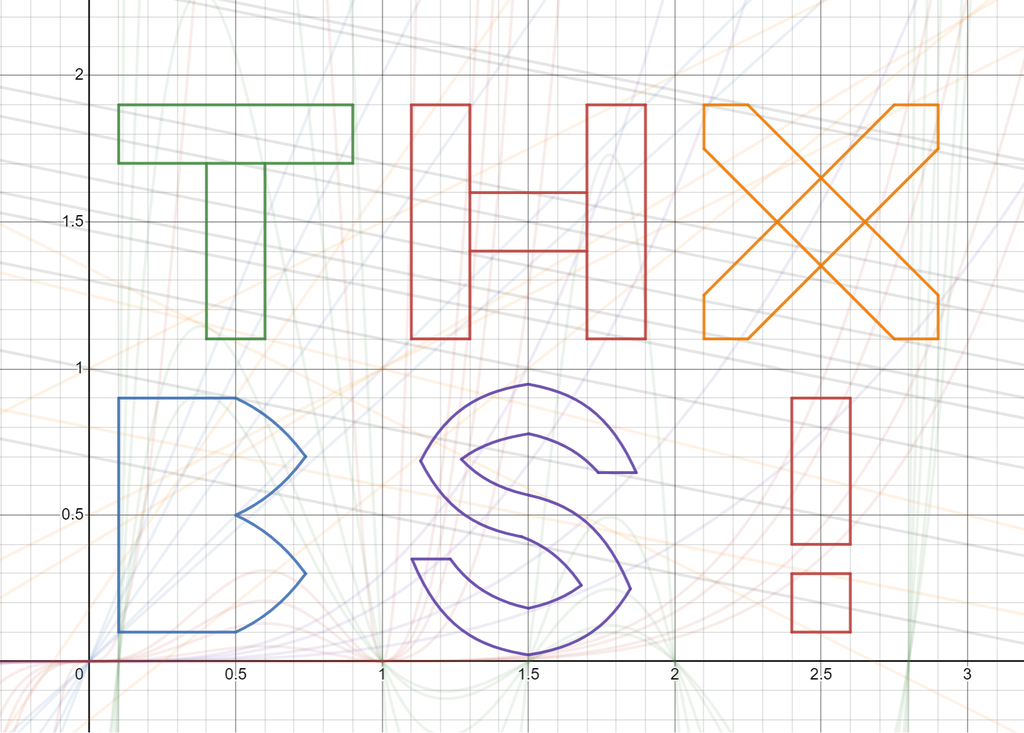

## Code

Data Creation:

```r
dat = read_excel("BattleshipDat.xlsx") |>
  select(x1, x2, x3, label)


set.seed(122)
factored <- dat |>
  mutate(
    label = as.factor(label),
    green = ifelse(label %in% c("x5sqig",
                                "x5sqig7",
                                "x5sqig0.4",
                                "x5sqig0.5",
                                "x5sqig2"),1,0),
    blue = ifelse(label %in% c("1line1",
                               "1line1.45",
                               "1line0.9",
                               "1line2",
                               "1line2.5"),1,0),
    purple = ifelse(label %in% c("x3sqig1",
                                 "x3sqig0.5",
                                 "x3sqig2",
                                 "x3sqig3"),1,0),
    orange = ifelse(label %in% c("2line1:1",
                                 "2line-1:1.34",
                                 "2line-1:0.5",
                                 "2line-0.4:0.8",
                                 "2line-0.5:1.25",
                                 "2line1.6:-0.2",
                                 "2line2.9:0.18",
                                 "2line1.2:0.4"),1,0),
    red = ifelse(label %in% c("2x5sqig1",
                              "2x5sqig6",
                              "2x5sqig2.5",
                              "2x5sqig4",
                              "2x5sqig80",
                              "2x5sqig0.014",
                              "2x5sqig0.018",
                              "2x5sqig0.0087",
                              "2x5sqig0.0067",
                              "2x5sqig0.0022"),1,0),
    black = ifelse(label %in% c("3line1",
                                "3line1.3",
                                "3line1.47",
                                "3line1.54",
                                "3line1.65",
                                "3line1.8",
                                "3line1.7",
                                "3line1.9",
                                "3line2.35",
                                "3line2.32"),1,0),
    x3 = if_else(is.na(x3), sample(c(1.00, 1.34, 0.50, 0.80, 1.25, -0.20),
                           nrow(dat),
                           replace=T), x3)
  )

beta0int = 0.1782962 # Main model intercept
#GREEN
beta0 = -2.52  #intercept
beta1 = 31.56  #x
beta2 = -69.33 #x^{2}
beta3 = 59.49  #x^{3}
beta4 = -22.2  #x^{4}
beta5 = 3      #x^{5}

#BLUE
beta6 = 1

#PURPLE
beta7 = 0.1

#ORANGE
beta8 = 1 #intercept
beta9 = 0.5   #slope

#RED
beta10 = 1.5
beta11 = -3
beta12 = 1.5

#BLACK
beta13 = 1
beta14 = -0.2

calcy <- factored |>
  mutate(
    y = beta0int +
          green*(beta5*x1^5 +
                   beta4*x1^4 +
                   beta3*x1^3 +
                   beta2*x1^2 +
                   beta1*x1 +
                   beta0)*x2 +
          blue*(beta6*x1)*x2 +
          purple*(beta7*x1^3)*x2 +
          orange*(beta8*x3 + beta9*x1*x2) +
          red*(beta12*x1^5 +
                   beta11*x1^4 +
                   beta10*x1^3)*x2 +
          black*(beta13*x2+beta14*x1)

  )


## HIDE THE DATA

# Create 3 main columns which, when added, equal mainX, when multiplied, equal the main interaction column
hidden <- calcy |>
  mutate(
    main1 = (runif(n = nrow(calcy)) - 1)*3,
    main2 = ((x1-main1) + sqrt( (x1-main1)^2 - 4*(x2/main1) ))/2,
    main3 = x1 - main1 - main2,
    mainadd = main1 + main2 + main3,
    mainmult = main1 * main2* main3
  )

for (i in 1:nrow(hidden)) {
  while (is.na(hidden[i, "main2"])) {
    hidden[i,"main1"] <- (runif(1)-1)*3
    hidden[i,"main2"] <- ((hidden[i,"x1"]-hidden[i,"main1"]) + sqrt( (hidden[i,"x1"]-hidden[i,"main1"])^2 - 4*(hidden[i,"x2"]/hidden[i,"main1"]) ))/2
  }
}

hidden <- hidden |>
  mutate(
    main3 = x1 - main1 - main2,
    mainadd = main1 + main2 + main3,
    mainmult = main1 * main2* main3
  )
hidden$main3 <- as.numeric(format(hidden$main3, scientific=F))

# Create 6 columns that sum to be the switch for the 6 types


for (i in 1:nrow(hidden)) {
  original_vector <- c(1, 2, 3, 4, 5)
  remaining_values <- original_vector
  for (j in 1:4) {
    sampled_value <- sample(remaining_values, 1)
    hidden[i, paste0("s", j)] <- sampled_value
    remaining_values <- remaining_values[remaining_values != sampled_value]
  }
  hidden[i, "s5"] <- remaining_values

  if (hidden[i, "green"] == 1) {
     hidden[i,"s1"] <- 0
     hidden[i,"s2"] <- 0
     hidden[i,"s3"] <- 0
     hidden[i,"s4"] <- 0
     hidden[i,"s5"] <- 0

  } else if (hidden[i, "blue"] == 1) {
        values <- c(1)
    ifelse(hidden[i, "s1"] %in% values,
           hidden[i,"s1"] <- 1,
           hidden[i,"s1"] <- 0)
    ifelse(hidden[i, "s2"] %in% values,
           hidden[i,"s2"] <- 1,
           hidden[i,"s2"] <- 0)
    ifelse(hidden[i, "s3"] %in% values,
           hidden[i,"s3"] <- 1,
           hidden[i,"s3"] <- 0)
    ifelse(hidden[i, "s4"] %in% values,
           hidden[i,"s4"] <- 1,
           hidden[i,"s4"] <- 0)
    ifelse(hidden[i, "s5"] %in% values,
           hidden[i,"s5"] <- 1,
           hidden[i,"s5"] <- 0)

  } else if (hidden[i, "orange"] == 1) {
        values <- c(1, 2)
    ifelse(hidden[i, "s1"] %in% values,
           hidden[i,"s1"] <- 1,
           hidden[i,"s1"] <- 0)
    ifelse(hidden[i, "s2"] %in% values,
           hidden[i,"s2"] <- 1,
           hidden[i,"s2"] <- 0)
    ifelse(hidden[i, "s3"] %in% values,
           hidden[i,"s3"] <- 1,
           hidden[i,"s3"] <- 0)
    ifelse(hidden[i, "s4"] %in% values,
           hidden[i,"s4"] <- 1,
           hidden[i,"s4"] <- 0)
    ifelse(hidden[i, "s5"] %in% values,
           hidden[i,"s5"] <- 1,
           hidden[i,"s5"] <- 0)

  } else if (hidden[i, "purple"] == 1) {
        values <- c(1, 2, 3)
    ifelse(hidden[i, "s1"] %in% values,
           hidden[i,"s1"] <- 1,
           hidden[i,"s1"] <- 0)
    ifelse(hidden[i, "s2"] %in% values,
           hidden[i,"s2"] <- 1,
           hidden[i,"s2"] <- 0)
    ifelse(hidden[i, "s3"] %in% values,
           hidden[i,"s3"] <- 1,
           hidden[i,"s3"] <- 0)
    ifelse(hidden[i, "s4"] %in% values,
           hidden[i,"s4"] <- 1,
           hidden[i,"s4"] <- 0)
    ifelse(hidden[i, "s5"] %in% values,
           hidden[i,"s5"] <- 1,
           hidden[i,"s5"] <- 0)

  } else if (hidden[i, "red"] == 1) {
        values <- c(1, 2, 3, 4)
    ifelse(hidden[i, "s1"] %in% values,
           hidden[i,"s1"] <- 1,
           hidden[i,"s1"] <- 0)
    ifelse(hidden[i, "s2"] %in% values,
           hidden[i,"s2"] <- 1,
           hidden[i,"s2"] <- 0)
    ifelse(hidden[i, "s3"] %in% values,
           hidden[i,"s3"] <- 1,
           hidden[i,"s3"] <- 0)
    ifelse(hidden[i, "s4"] %in% values,
           hidden[i,"s4"] <- 1,
           hidden[i,"s4"] <- 0)
    ifelse(hidden[i, "s5"] %in% values,
           hidden[i,"s5"] <- 1,
           hidden[i,"s5"] <- 0)

  } else if (hidden[i, "black"] == 1) {
        values <- c(1, 2, 3, 4, 5)
    ifelse(hidden[i, "s1"] %in% values,
           hidden[i,"s1"] <- 1,
           hidden[i,"s1"] <- 0)
    ifelse(hidden[i, "s2"] %in% values,
           hidden[i,"s2"] <- 1,
           hidden[i,"s2"] <- 0)
    ifelse(hidden[i, "s3"] %in% values,
           hidden[i,"s3"] <- 1,
           hidden[i,"s3"] <- 0)
    ifelse(hidden[i, "s4"] %in% values,
           hidden[i,"s4"] <- 1,
           hidden[i,"s4"] <- 0)
    ifelse(hidden[i, "s5"] %in% values,
           hidden[i,"s5"] <- 1,
           hidden[i,"s5"] <- 0)

  }
}

# Select only needed columns
hidden <- hidden |>
  select(y, main1, main2, main3, s1, s2, s3, s4, s5, x3)

# FINALIZE ORDER

DC122 <- c("...if", "then", "he", "shall", "be", "thrust", "from", "thee", "by", "the", "sword,", "and", "thou", "be", "dragged", "to", "prison,", "and", "thine", "enemies", "prowl", "around", "thee", "like", "wolves", "for", "the", "blood", "of", "the", "lamb;", "And", "if", "thou", "shouldst", "be", "cast", "into", "the", "pit,", "or", "into", "the", "hands", "of", "murderers,", "and", "the", "sentence", "of", "death", "passed", "upon", "thee;", "if", "thou", "be", "cast", "into", "the", "deep;", "if", "the", "billowing", "surge", "conspire", "against", "thee;", "if", "fierce", "winds", "become", "thine", "enemy;", "if", "the", "heavens", "gather", "blackness,", "and", "all", "the", "elements", "combine", "to", "hedge", "up", "the", "way;", "and", "above", "all,", "if", "the", "very", "jaws", "of", "hell", "shall", "gape", "open", "the", "mouth", "wide", "after", "thee,", "know", "thou,", "my", "son,", "that", "all", "these", "things", "shall", "give", "thee", "experience,", "and", "shall", "be", "for", "thy", "good.", "The", "Son", "of", "Man", "hath", "descended", "below", "them", "all.", "Art", "thou", "greater", "than", "he?", "Therefore,", "hold", "on", "thy", "way,", "and", "the", "priesthood", "shall", "remain", "with", "thee;", "for", "their", "bounds", "are", "set,", "they", "cannot", "pass.", "Thy", "days", "are", "known,", "and", "thy", "years", "shall", "not", "be", "numbered", "less;", "therefore,", "fear", "not", "what", "man", "can", "do,", "for", "God", "shall", "be", "with", "you", "forever", "and", "ever.'", "(D&C", "122", "6-9)", "-", "-", "-", "-", "-", "-", "-", "-", "-", "-", "-", "-", "-", "-", "-", "-", "-", "-", "-", "-", "-", "-", "-", "-", "-", "-", "-", "-", "-", "-", "-", "-", "-", "-", "-", "-", "-", "-", "-", "-", "-", "-", "-", "-", "-", "-", "-", "Thank", "you", "Brother", "Saunders!")



final <- hidden |>
  mutate(
    x7 = x3,
    x1 = main1,
    x2 = s1,
    x3 = 0,
    x4 = s2,
    x5 = s3,
    x6 = main2,
    x8 = main3,
    x9 = s4,
    x10 = s5
  )

final <- final[, c("y", "x1", "x2", "x3", "x4", "x5", "x6", "x7", "x8", "x9", "x10")]
final <- final[sample(nrow(final)), ]

final$x3 <- as.factor(DC122)

write.csv(final, file = "ThereIsChaosInTheOrder.csv", row.names = FALSE)
```

Pulling the Truth from the Data:

```r
df <- final |>
  mutate(
    switches = x2 + x4 + x5 + x9 + x10,
    mainX = x1 + x6 + x8,
    lineInt = x1 * x6 * x8,
    green = ifelse(switches == 0, 1, 0),
    blue = ifelse(switches == 1, 1, 0),
    orange = ifelse(switches == 2, 1, 0),
    purple = ifelse(switches == 3, 1, 0),
    red = ifelse(switches == 4, 1, 0),
    black = ifelse(switches == 5, 1, 0),
  )

mylm <- lm(y~green:I(mainX^5):lineInt + green:I(mainX^4):lineInt
          + green:I(mainX^3):lineInt + green:I(mainX^2):lineInt
          + green:I(mainX):lineInt + green:lineInt +
          blue:mainX:lineInt +
          purple:I(mainX^3):lineInt +
          orange:I(x7) + orange:mainX:lineInt +
          red:I(mainX^5):lineInt + red:I(mainX^4):lineInt + red:I(mainX^3):lineInt +
          black:lineInt+black:mainX, data=df)
summary(mylm)
```

```
##
## Call:
## lm(formula = y ~ green:I(mainX^5):lineInt + green:I(mainX^4):lineInt +
##     green:I(mainX^3):lineInt + green:I(mainX^2):lineInt + green:I(mainX):lineInt +
##     green:lineInt + blue:mainX:lineInt + purple:I(mainX^3):lineInt +
##     orange:I(x7) + orange:mainX:lineInt + red:I(mainX^5):lineInt +
##     red:I(mainX^4):lineInt + red:I(mainX^3):lineInt + black:lineInt +
##     black:mainX, data = df)
##
## Residuals:
##        Min         1Q     Median         3Q        Max
## -6.571e-08 -2.800e-10 -6.100e-11  1.790e-10  2.815e-08
##
## Coefficients:
##                             Estimate Std. Error    t value Pr(>|t|)
## (Intercept)                1.783e-01  9.402e-10  189644657   <2e-16 ***
## green:lineInt             -2.520e+00  9.123e-09 -276213630   <2e-16 ***
## orange:I(x7)               1.000e+00  1.482e-09  674639587   <2e-16 ***
## lineInt:black              1.000e+00  1.239e-09  807276011   <2e-16 ***
## mainX:black               -2.000e-01  1.006e-09 -198714091   <2e-16 ***
## green:I(mainX^5):lineInt   3.000e+00  9.208e-09  325817518   <2e-16 ***
## green:lineInt:I(mainX^4)  -2.220e+01  6.599e-08 -336408905   <2e-16 ***
## green:lineInt:I(mainX^3)   5.949e+01  1.689e-07  352217936   <2e-16 ***
## green:lineInt:I(mainX^2)  -6.933e+01  1.860e-07 -372774161   <2e-16 ***
## green:lineInt:I(mainX)     3.156e+01  8.102e-08  389544471   <2e-16 ***
## lineInt:blue:mainX         1.000e+00  1.069e-09  935647223   <2e-16 ***
## lineInt:I(mainX^3):purple  1.000e-01  1.696e-10  589570038   <2e-16 ***
## lineInt:mainX:orange       5.000e-01  5.582e-10  895744790   <2e-16 ***
## I(mainX^5):lineInt:red     1.500e+00  1.749e-09  857651830   <2e-16 ***
## lineInt:I(mainX^4):red    -3.000e+00  3.534e-09 -848829843   <2e-16 ***
## lineInt:I(mainX^3):red     1.500e+00  1.784e-09  840612400   <2e-16 ***
## ---
## Signif. codes:  0 '***' 0.001 '**' 0.01 '*' 0.05 '.' 0.1 ' ' 1
##
## Residual standard error: 6.234e-09 on 224 degrees of freedom
## Multiple R-squared:      1,  Adjusted R-squared:      1
## F-statistic: 1.305e+17 on 15 and 224 DF,  p-value: < 2.2e-16
```

## R Plot

### True and Estimated Model

```r
b <- coef(mylm)

ggplot(df, aes(x = mainX, y = y)) +
  geom_point(aes(color = as.factor(switches)), size=2) +
  # GREEN
  stat_function(fun = function(x) 0.1782962 +
                  beta5 * x^5 +
                  beta4 * x^4 +
                  beta3 * x^3 +
                  beta2 * x^2 +
                  beta1 * x +
                  beta0,
                alpha = 0.2,
                color = "forestgreen",
                aes(color="1")) +
  stat_function(fun = function(x) 0.1782962 +
                  beta5 * x^5 * 7 +
                  beta4 * x^4 * 7 +
                  beta3 * x^3 * 7 +
                  beta2 * x^2 * 7 +
                  beta1 * x * 7 +
                  beta0 * 7,
                alpha = 0.2,
                color = "forestgreen",
                aes(color="1")) +
  stat_function(fun = function(x) 0.1782962 +
                  beta5 * x^5 * 2 +
                  beta4 * x^4 * 2 +
                  beta3 * x^3 * 2 +
                  beta2 * x^2 * 2 +
                  beta1 * x * 2 +
                  beta0 * 2,
                alpha = 0.2,
                color = "forestgreen",
                aes(color="1")) +
  stat_function(fun = function(x) 0.1782962 +
                  beta5 * x^5 * 0.4 +
                  beta4 * x^4 * 0.4 +
                  beta3 * x^3 * 0.4 +
                  beta2 * x^2 * 0.4 +
                  beta1 * x * 0.4 +
                  beta0 * 0.4,
                alpha = 0.2,
                color = "forestgreen",
                aes(color="1")) +
  stat_function(fun = function(x) 0.1782962 +
                  beta5 * x^5 * 0.5 +
                  beta4 * x^4 * 0.5 +
                  beta3 * x^3 * 0.5 +
                  beta2 * x^2 * 0.5 +
                  beta1 * x * 0.5 +
                  beta0 * 0.5,
                alpha = 0.2,
                color = "forestgreen",
                aes(color="1")) +
  # BLUE
  stat_function(fun = function(x) 0.1782962 +
                  beta6 * x * 1,
                alpha = 0.2,
                color = "skyblue3",
                aes(color="2")) +
  stat_function(fun = function(x) 0.1782962 +
                  beta6 * x * 1.45,
                alpha = 0.2,
                color = "skyblue3",
                aes(color="2")) +
  stat_function(fun = function(x) 0.1782962 +
                  beta6 * x * 0.9,
                alpha = 0.2,
                color = "skyblue3",
                aes(color="2")) +
  stat_function(fun = function(x) 0.1782962 +
                  beta6 * x * 2,
                alpha = 0.2,
                color = "skyblue3",
                aes(color="2")) +
  stat_function(fun = function(x) 0.1782962 +
                  beta6 * x * 2.5,
                alpha = 0.2,
                color = "skyblue3",
                aes(color="2")) +
  stat_function(fun = function(x) 0.1782962 +
                  beta8 * 1 + beta9 * x * 1,
                alpha = 0.2,
                color = "orange",
                aes(color="3")) +
  stat_function(fun = function(x) 0.1782962 +
                  beta8 * 1.34 + beta9 * x * -1,
                alpha = 0.2,
                color = "orange",
                aes(color="3")) +
  stat_function(fun = function(x) 0.1782962 +
                  beta8 * 0.5 + beta9 * x * 1,
                alpha = 0.2,
                color = "orange",
                aes(color="3")) +
  stat_function(fun = function(x) 0.1782962 +
                  beta8 * 0.8 + beta9 * x * -0.4,
                alpha = 0.2,
                color = "orange",
                aes(color="3")) +
  stat_function(fun = function(x) 0.1782962 +
                  beta8 * 1.25 + beta9 * x * -0.5,
                alpha = 0.2,
                color = "orange",
                aes(color="3")) +
  stat_function(fun = function(x) 0.1782962 +
                  beta8 * -0.2 + beta9 * x * 1.6,
                alpha = 0.2,
                color = "orange",
                aes(color="3")) +
  stat_function(fun = function(x) 0.1782962 +
                  beta8 * 0.18 + beta9 * x * 2.9,
                alpha = 0.2,
                color = "orange",
                aes(color="3")) +
  stat_function(fun = function(x) 0.1782962 +
                  beta8 * 0.4 + beta9 * x * 1.2,
                alpha = 0.2,
                color = "orange",
                aes(color="3")) +
  stat_function(fun = function(x) 0.1782962 +
                beta8 * 0.4 + beta9 * x * 1.2,
              alpha = 0.2,
              color = "orange",
              aes(color="3")) +
  stat_function(fun = function(x) 0.1782962 +
                  beta7 * x^3 * 1,
                alpha = 0.2,
                color = "purple",
                aes(color="4")) +
  stat_function(fun = function(x) 0.1782962 +
                  beta7 * x^3 * 0.5,
                alpha = 0.2,
                color = "purple",
                aes(color="4")) +
  stat_function(fun = function(x) 0.1782962 +
                  beta7 * x^3 * 2,
                alpha = 0.2,
                color = "purple",
                aes(color="4")) +
  stat_function(fun = function(x) 0.1782962 +
                  beta7 * x^3 * 3,
                alpha = 0.2,
                color = "purple",
                aes(color="4")) +
  stat_function(fun = function(x) 0.1782962 +
                  (beta12 * x^5 + beta11 * x^4 + beta10 * x^3) * 1,
                alpha = 0.2,
                color = "red",
                aes(color="5")) +
  stat_function(fun = function(x) 0.1782962 +
                  (beta12 * x^5 + beta11 * x^4 + beta10 * x^3) * 6,
                alpha = 0.2,
                color = "red",
                aes(color="5")) +
  stat_function(fun = function(x) 0.1782962 +
                  (beta12 * x^5 + beta11 * x^4 + beta10 * x^3) * 2.5,
                alpha = 0.2,
                color = "red",
                aes(color="5")) +
  stat_function(fun = function(x) 0.1782962 +
                  (beta12 * x^5 + beta11 * x^4 + beta10 * x^3) * 4,
                alpha = 0.2,
                color = "red",
                aes(color="5")) +
  stat_function(fun = function(x) 0.1782962 +
                  (beta12 * x^5 + beta11 * x^4 + beta10 * x^3) * 80,
                alpha = 0.2,
                color = "red",
                aes(color="5")) +
  stat_function(fun = function(x) 0.1782962 +
                  (beta12 * x^5 + beta11 * x^4 + beta10 * x^3) * 0.014,
                alpha = 0.2,
                color = "red",
                aes(color="5")) +
  stat_function(fun = function(x) 0.1782962 +
                  (beta12 * x^5 + beta11 * x^4 + beta10 * x^3) * 0.018,
                alpha = 0.2,
                color = "red",
                aes(color="5")) +
  stat_function(fun = function(x) 0.1782962 +
                  (beta12 * x^5 + beta11 * x^4 + beta10 * x^3) * 0.0087,
                alpha = 0.2,
                color = "red",
                aes(color="5")) +
  stat_function(fun = function(x) 0.1782962 +
                  (beta12 * x^5 + beta11 * x^4 + beta10 * x^3) * 0.0067,
                alpha = 0.2,
                color = "red",
                aes(color="5")) +
  stat_function(fun = function(x) 0.1782962 +
                  (beta12 * x^5 + beta11 * x^4 + beta10 * x^3) * 0.0022,
                alpha = 0.2,
                color = "red",
                aes(color="5")) +
stat_function(fun = function(x) 0.1782962 +
                  beta13 * 1 + beta14 * x,
                alpha = 0.2,
                color = "gray50",
                aes(color = "6")) +
  stat_function(fun = function(x) 0.1782962 +
                  beta13 * 1.3 + beta14 * x,
                alpha = 0.2,
                color = "gray50",
                aes(color = "6")) +
  stat_function(fun = function(x) 0.1782962 +
                  beta13 * 1.47 + beta14 * x,
                alpha = 0.2,
                color = "gray50",
                aes(color = "6")) +
  stat_function(fun = function(x) 0.1782962 +
                  beta13 * 1.54 + beta14 * x,
                alpha = 0.2,
                color = "gray50",
                aes(color = "6")) +
  stat_function(fun = function(x) 0.1782962 +
                  beta13 * 1.65 + beta14 * x,
                alpha = 0.2,
                color = "gray50",
                aes(color = "6")) +
  stat_function(fun = function(x) 0.1782962 +
                  beta13 * 1.8 + beta14 * x,
                alpha = 0.2,
                color = "gray50",
                aes(color = "6")) +
  stat_function(fun = function(x) 0.1782962 +
                  beta13 * 0.7 + beta14 * x,
                alpha = 0.2,
                color = "gray50",
                aes(color = "6")) +
  stat_function(fun = function(x) 0.1782962 +
                  beta13 * 1.9 + beta14 * x,
                alpha = 0.2,
                color = "gray50",
                aes(color = "6")) +
  stat_function(fun = function(x) 0.1782962 +
                  beta13 * 2.35 + beta14 * x,
                alpha = 0.2,
                color = "gray50",
                aes(color = "6")) +
  stat_function(fun = function(x) 0.1782962 +
                  beta13 * 2.32 + beta14 * x,
                alpha = 0.2,
                color = "gray50",
                aes(color = "6")) +
  # GREEN
  stat_function(fun = function(x) b[1] +
                  b[6] * x^5 +
                  b[7] * x^4 +
                  b[8] * x^3 +
                  b[9] * x^2 +
                  b[10] * x +
                  b[2],
                alpha = 0.2,
                color = "forestgreen",
                aes(color = "1"), linetype = "dashed") +
  stat_function(fun = function(x) b[1] +
                  b[6] * x^5 * 7 +
                  b[7] * x^4 * 7 +
                  b[8] * x^3 * 7 +
                  b[9] * x^2 * 7 +
                  b[10] * x * 7 +
                  b[2] * 7,
                alpha = 0.2,
                color = "forestgreen",
                aes(color = "1"), linetype = "dashed") +
  stat_function(fun = function(x) b[1] +
                  b[6] * x^5 * 2 +
                  b[7] * x^4 * 2 +
                  b[8] * x^3 * 2 +
                  b[9] * x^2 * 2 +
                  b[10] * x * 2 +
                  b[2] * 2,
                alpha = 0.2,
                color = "forestgreen",
                aes(color = "1"), linetype = "dashed") +
  stat_function(fun = function(x) b[1] +
                  b[6] * x^5 * 0.4 +
                  b[7] * x^4 * 0.4 +
                  b[8] * x^3 * 0.4 +
                  b[9] * x^2 * 0.4 +
                  b[10] * x * 0.4 +
                  b[2] * 0.4,
                alpha = 0.2,
                color = "forestgreen",
                aes(color = "1"), linetype = "dashed") +
  stat_function(fun = function(x) b[1] +
                  b[6] * x^5 * 0.5 +
                  b[7] * x^4 * 0.5 +
                  b[8] * x^3 * 0.5 +
                  b[9] * x^2 * 0.5 +
                  b[10] * x * 0.5 +
                  b[2] * 0.5,
                alpha = 0.2,
                color = "forestgreen",
                aes(color = "1"), linetype = "dashed") +
  # BLUE
  stat_function(fun = function(x) b[1] +
                  b[11] * x * 1,
                alpha = 0.2,
                color = "skyblue3",
                aes(color = "2"), linetype = "dashed") +
  stat_function(fun = function(x) b[1] +
                  b[11] * x * 1.45,
                alpha = 0.2,
                color = "skyblue3",
                aes(color = "2"), linetype = "dashed") +
  stat_function(fun = function(x) b[1] +
                  b[11] * x * 0.9,
                alpha = 0.2,
                color = "skyblue3",
                aes(color = "2"), linetype = "dashed") +
  stat_function(fun = function(x) b[1] +
                  b[11] * x * 2,
                alpha = 0.2,
                color = "skyblue3",
                aes(color = "2"), linetype = "dashed") +
  stat_function(fun = function(x) b[1] +
                  b[11] * x * 2.5,
                alpha = 0.2,
                color = "skyblue3",
```

```r
                aes(color = "2"), linetype = "dashed") +
  # ORANGE
  stat_function(fun = function(x) b[1] +
                  b[3] * 1 + b[13] * x * 1,
                alpha = 0.2,
                color = "orange",
                aes(color = "3"), linetype = "dashed") +
  stat_function(fun = function(x) b[1] +
                  b[3] * 1.34 + b[13] * x * -1,
                alpha = 0.2,
                color = "orange",
                aes(color = "3"), linetype = "dashed") +
  stat_function(fun = function(x) b[1] +
                  b[3] * 0.5 + b[13] * x * 1,
                alpha = 0.2,
                color = "orange",
                aes(color = "3"), linetype = "dashed") +
  stat_function(fun = function(x) b[1] +
                  b[3] * 0.8 + b[13] * x * -0.4,
                alpha = 0.2,
                color = "orange",
                aes(color = "3"), linetype = "dashed") +
  stat_function(fun = function(x) b[1] +
                  b[3] * 1.25 + b[13] * x * -0.5,
                alpha = 0.2,
                color = "orange",
                aes(color = "3"), linetype = "dashed") +
  stat_function(fun = function(x) b[1] +
                  b[3] * -0.2 + b[13] * x * 1.6,
                alpha = 0.2,
                color = "orange",
                aes(color = "3"), linetype = "dashed") +
  stat_function(fun = function(x) b[1] +
                  b[3] * 0.18 + b[13] * x * 2.9,
                alpha = 0.2,
                color = "orange",
                aes(color = "3"), linetype = "dashed") +
  stat_function(fun = function(x) b[1] +
                  b[3] * 0.4 + b[13] * x * 1.2,
                alpha = 0.2,
                color = "orange",
                aes(color = "3"), linetype = "dashed") +
  # PURPLE
  stat_function(fun = function(x) b[1] +
                  b[12] * x^3 * 1,
                alpha = 0.2,
                color = "purple",
                aes(color = "4"), linetype = "dashed") +
  stat_function(fun = function(x) b[1] +
                  b[12] * x^3 * 0.5,
                alpha = 0.2,
                color = "purple",
                aes(color = "4"), linetype = "dashed") +
  stat_function(fun = function(x) b[1] +
                  b[12] * x^3 * 2,
                alpha = 0.2,
                color = "purple",
                aes(color = "4"), linetype = "dashed") +
  stat_function(fun = function(x) b[1] +
                  b[12] * x^3 * 3,
                alpha = 0.2,
                color = "purple",
                aes(color = "4"), linetype = "dashed") +
  # RED
  stat_function(fun = function(x) b[1] +
                  (b[14] * x^5 + b[15] * x^4 + b[16] * x^3) * 1,
                alpha = 0.2,
                color = "red",
                aes(color = "5"), linetype = "dashed") +
  stat_function(fun = function(x) b[1] +
                  (b[14] * x^5 + b[15] * x^4 + b[16] * x^3) * 6,
                alpha = 0.2,
                color = "red",
                aes(color = "5"), linetype = "dashed") +
  stat_function(fun = function(x) b[1] +
                  (b[14] * x^5 + b[15] * x^4 + b[16] * x^3) * 2.5,
                alpha = 0.2,
                color = "red",
                aes(color = "5"), linetype = "dashed") +
  stat_function(fun = function(x) b[1] +
                  (b[14] * x^5 + b[15] * x^4 + b[16] * x^3) * 4,
                alpha = 0.2,
                color = "red",
                aes(color = "5"), linetype = "dashed") +
  stat_function(fun = function(x) b[1] +
                  (b[14] * x^5 + b[15] * x^4 + b[16] * x^3) * 80,
                alpha = 0.2,
                color = "red",
                aes(color = "5"), linetype = "dashed") +
  stat_function(fun = function(x) b[1] +
                  (b[14] * x^5 + b[15] * x^4 + b[16] * x^3) * 0.014,
                alpha = 0.2,
                color = "red",
                aes(color = "5"), linetype = "dashed") +
  stat_function(fun = function(x) b[1] +
                  (b[14] * x^5 + b[15] * x^4 + b[16] * x^3) * 0.018,
                alpha = 0.2,
                color = "red",
                aes(color = "5"), linetype = "dashed") +
  stat_function(fun = function(x) b[1] +
                  (b[14] * x^5 + b[15] * x^4 + b[16] * x^3) * 0.0087,
                alpha = 0.2,
                color = "red",
                aes(color = "5"), linetype = "dashed") +
  stat_function(fun = function(x) b[1] +
                  (b[14] * x^5 + b[15] * x^4 + b[16] * x^3) * 0.0067,
                alpha = 0.2,
                color = "red",
                aes(color = "5"), linetype = "dashed") +
    stat_function(fun = function(x) b[1] +
                  (b[14] * x^5 + b[15] * x^4 + b[16] * x^3) * 0.0022,
                alpha = 0.2,
                color = "red",
                aes(color = "5"), linetype = "dashed") +
  # GRAY
  stat_function(fun = function(x) b[1] +
                  b[4] * 1 + b[5] * x,
                alpha = 0.2,
                color = "gray50",
                aes(color = "6"), linetype = "dashed") +
  stat_function(fun = function(x) b[1] +
                  b[4] * 1.3 + b[5] * x,
                alpha = 0.2,
                color = "gray50",
                aes(color = "6"), linetype = "dashed") +
  stat_function(fun = function(x) b[1] +
                  b[4] * 1.47 + b[5] * x,
                alpha = 0.2,
                color = "gray50",
                aes(color = "6"), linetype = "dashed") +
  stat_function(fun = function(x) b[1] +
                  b[4] * 1.54 + b[5] * x,
                alpha = 0.2,
                color = "gray50",
                aes(color = "6"), linetype = "dashed") +
  stat_function(fun = function(x) b[1] +
                  b[4] * 1.65 + b[5] * x,
                alpha = 0.2,
                color = "gray50",
                aes(color = "6"), linetype = "dashed") +
  stat_function(fun = function(x) b[1] +
                  b[4] * 1.8 + b[5] * x,
                alpha = 0.2,
                color = "gray50",
                aes(color = "6"), linetype = "dashed") +
  stat_function(fun = function(x) b[1] +
                  b[4] * 0.7 + b[5] * x,
                alpha = 0.2,
                color = "gray50",
                aes(color = "6"), linetype = "dashed") +
  stat_function(fun = function(x) b[1] +
                  b[4] * 1.9 + b[5] * x,
                alpha = 0.2,
                color = "gray50",
                aes(color = "6"), linetype = "dashed") +
  stat_function(fun = function(x) b[1] +
                  b[4] * 2.35 + b[5] * x,
                alpha = 0.2,
                color = "gray50",
                aes(color = "6"), linetype = "dashed") +
  stat_function(fun = function(x) b[1] +
                  b[4] * 2.32 + b[5] * x,
                alpha = 0.2,
                color = "gray50",
                aes(color = "6"), linetype = "dashed") +
  scale_y_continuous(limits = c(0, 2.2)) +
  scale_color_manual(values = c("forestgreen", "skyblue3", "orange", "purple", "red", "gray50")) +
  theme_classic()
```

## Math Model

Write out your “true” model in mathematical form. Make sure it matches your code. This could be “painful” if you chose a complicated model.

## Finding the Hidden the Model

Here I will walk through step by step how one would get to my true model, starting from the dataset I gave them.

Lets begin by looking at the dataset, and graphing a pairs plot:

```r
final
```

```
## # A tibble: 240 × 11
##        y      x1    x2 x3        x4    x5    x6    x7      x8    x9   x10
##    <dbl>   <dbl> <dbl> <fct>  <dbl> <dbl> <dbl> <dbl>   <dbl> <dbl> <dbl>
##  1 0.694 -0.446      1 ...if      1     1  3.37  1.34 -1.66       0     1
##  2 0.503 -2.77       0 then       1     1  3.19  0.18 -0.328      0     0
##  3 0.858 -1.61       1 he         1     1  1.93  1.34 -0.225      1     1
##  4 2.08  -2.34       0 shall      1     0  5.22  0.5  -0.0817     0     1
##  5 0.352 -0.364      1 be         1     0  2.62  0.5  -1.05       1     0
##  6 0.768 -1.72       0 thrust     0     0  2.46  1.34 -0.0945     0     0
##  7 1.34  -0.0233     1 from       1     1  2.92  1    -0.206      0     1
##  8 1.28  -1.20       1 thee       0     1  4.11  1.25 -0.101      1     0
##  9 1.28  -1.66       1 by         1     1  4.09  0.5  -0.226      1     1
## 10 1.58  -1.39       1 the        0     1  3.65 -0.2  -0.590      1     0
## # ℹ 230 more rows
```

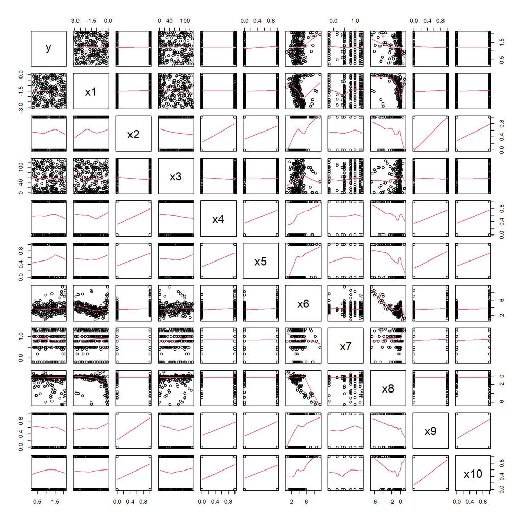

```r
pairs(final, panel=panel.smooth)
```

Notice we don’t even see the “THX BS!” text from the model; finding that text requires some work.

Normally at this point you would try coloring by different categorical variables to see if there are any trends in the data, but to progress here, we need to mutate some new columns.

First, we add together the three truly quantitative columns (note this does not include x3 or x7, as one of those is text, and the other is categorical). Now, lets graph this new x column against y.

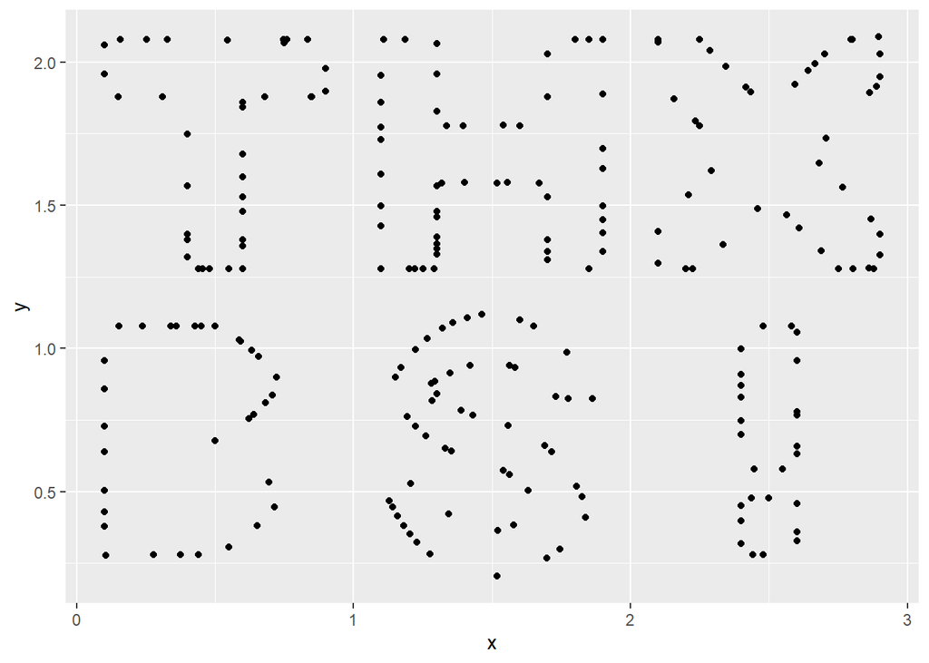

```r
df<-final |>
  mutate(
    x=x1+x6+x8,
  )
ggplot(df,aes(x=x,y=y)) +
  geom_point()
```

Now, to find how this text was written with lines. I used 6 different switches to activate different sets of lines to create this model. Finding those switches requires two more column mutations. First, we add together all the “1, 0” switch columns, which gives us a new column with values between 0 and 5. Each of these values is a switch. Lets graph it:

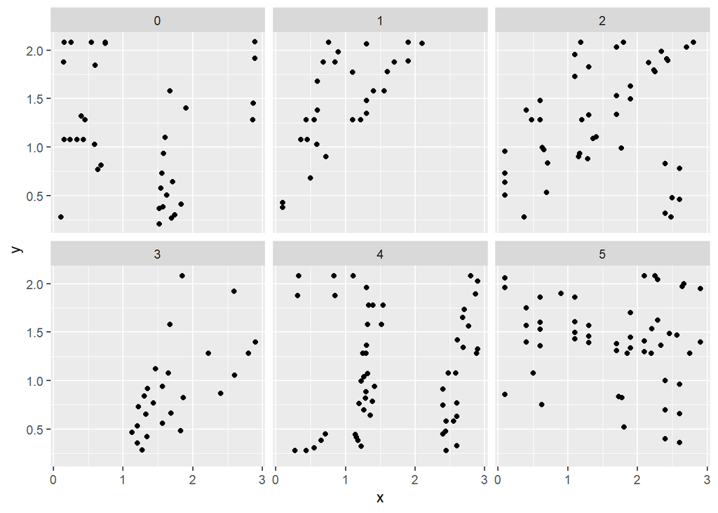

```r
df<-final |>
  mutate(
    x=x1+x6+x8,
    switches=x2+x4+x5+x9+x10
  )

ggplot(df,aes(x=x,y=y))+
  geom_point()+
  facet_wrap(
    ~switches
  )
```

Some may be hard to see how they are made by the same function, but we can see that switch 5 was made with staggered parallel lines. To see what points belong to each line, we need our last mutated column, which comes by multiplying the same 3 lines that we added together to create the main x value with the “THX BS!” text.

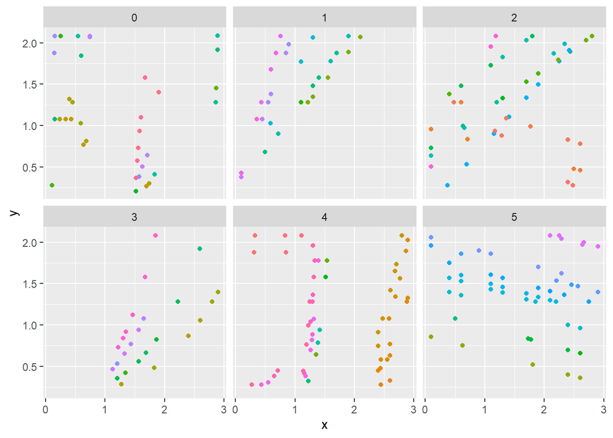

```r
df<-final |>
  mutate(
    x=x1+x6+x8,
    switches=x2+x4+x5+x9+x10,
    mult=x1*x6*x8
  )

ggplot(df,aes(x=x,y=y))+
  geom_point(aes(color=as.factor(mult)),show.legend = F)+
  facet_wrap(
    ~switches
  )
```

See **“R Plot”** to see these lines graphed and color coded.

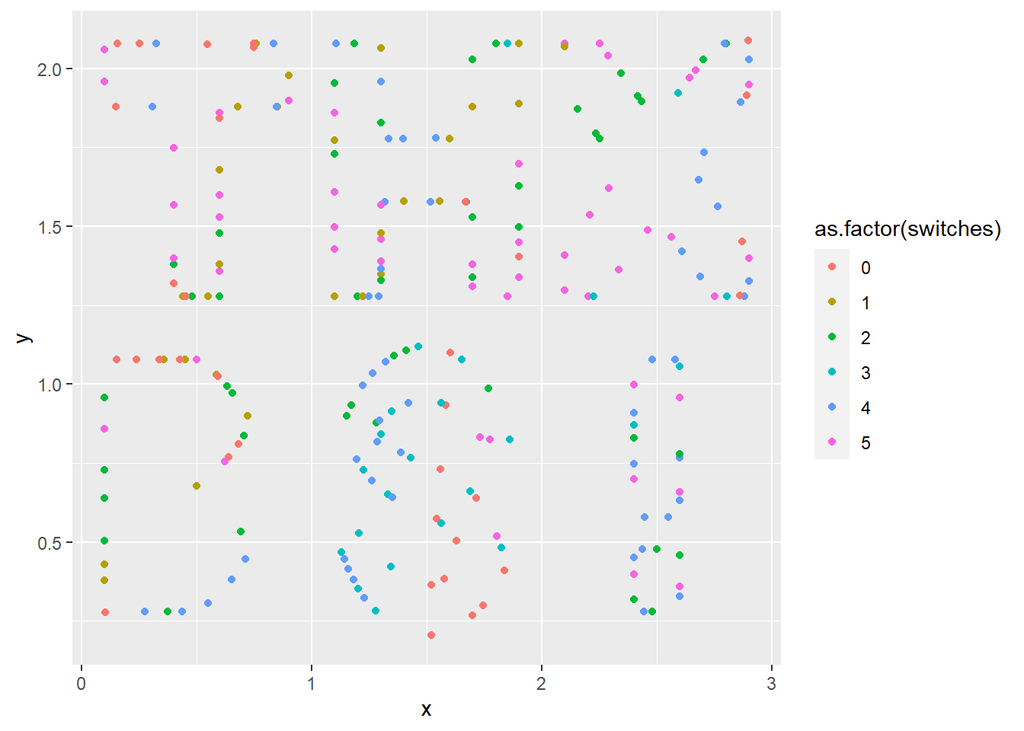

```r
ggplot(df,aes(x=x,y=y))+
  geom_point(aes(color=as.factor(switches)))
```

## Results

Once the Regression Battleship competition is completed, you will be given instructions on how to complete this section. The basic idea is to compare the three guesses at your true model (from two peers, and your teacher) to decide who won (i.e., who had the closest guess).

### New Data Creation

```r
#
dat = read_excel("BattleshipDat.xlsx") |>
  select(x1, x2, x3, label)


set.seed(1221)
factored <- dat |>
  mutate(
    label = as.factor(label),
    green = ifelse(label %in% c("x5sqig",
                                "x5sqig7",
                                "x5sqig0.4",
                                "x5sqig0.5",
                                "x5sqig2"),1,0),
    blue = ifelse(label %in% c("1line1",
                               "1line1.45",
                               "1line0.9",
                               "1line2",
                               "1line2.5"),1,0),
    purple = ifelse(label %in% c("x3sqig1",
                                 "x3sqig0.5",
                                 "x3sqig2",
                                 "x3sqig3"),1,0),
    orange = ifelse(label %in% c("2line1:1",
                                 "2line-1:1.34",
                                 "2line-1:0.5",
                                 "2line-0.4:0.8",
                                 "2line-0.5:1.25",
                                 "2line1.6:-0.2",
                                 "2line2.9:0.18",
                                 "2line1.2:0.4"),1,0),
    red = ifelse(label %in% c("2x5sqig1",
                              "2x5sqig6",
                              "2x5sqig2.5",
                              "2x5sqig4",
                              "2x5sqig80",
                              "2x5sqig0.014",
                              "2x5sqig0.018",
                              "2x5sqig0.0087",
                              "2x5sqig0.0067",
                              "2x5sqig0.0022"),1,0),
    black = ifelse(label %in% c("3line1",
                                "3line1.3",
                                "3line1.47",
                                "3line1.54",
                                "3line1.65",
                                "3line1.8",
                                "3line1.7",
                                "3line1.9",
                                "3line2.35",
                                "3line2.32"),1,0),
    x3 = if_else(is.na(x3), sample(c(1.00, 1.34, 0.50, 0.80, 1.25, -0.20),
                           nrow(dat),
                           replace=T), x3)
  )

beta0int = 0.1782962 # Main model intercept
#GREEN
beta0 = -2.52  #intercept
beta1 = 31.56  #x
beta2 = -69.33 #x^{2}
beta3 = 59.49  #x^{3}
beta4 = -22.2  #x^{4}
beta5 = 3      #x^{5}

#BLUE
beta6 = 1

#PURPLE
beta7 = 0.1

#ORANGE
beta8 = 1 #intercept
beta9 = 0.5   #slope

#RED
beta10 = 1.5
beta11 = -3
beta12 = 1.5

#BLACK
beta13 = 1
beta14 = -0.2

calcy <- factored |>
  mutate(
    x1=x1+0.2,
    y = beta0int +
          green*(beta5*x1^5 +
                   beta4*x1^4 +
                   beta3*x1^3 +
                   beta2*x1^2 +
                   beta1*x1 +
                   beta0)*x2 +
          blue*(beta6*x1)*x2 +
          purple*(beta7*x1^3)*x2 +
          orange*(beta8*x3 + beta9*x1*x2) +
          red*(beta12*x1^5 +
                   beta11*x1^4 +
                   beta10*x1^3)*x2 +
          black*(beta13*x2+beta14*x1),
  )


## HIDE THE DATA

# Create 3 main columns which, when added, equal mainX, when multiplied, equal the main interaction column
hidden <- calcy |>
  mutate(
    main1 = (runif(n = nrow(calcy)) - 1)*3,
    main2 = ((x1-main1) + sqrt( (x1-main1)^2 - 4*(x2/main1) ))/2,
    main3 = x1 - main1 - main2,
    mainadd = main1 + main2 + main3,
    mainmult = main1 * main2* main3
  )

for (i in 1:nrow(hidden)) {
  while (is.na(hidden[i, "main2"])) {
    hidden[i,"main1"] <- (runif(1)-1)*3
    hidden[i,"main2"] <- ((hidden[i,"x1"]-hidden[i,"main1"]) + sqrt( (hidden[i,"x1"]-hidden[i,"main1"])^2 - 4*(hidden[i,"x2"]/hidden[i,"main1"]) ))/2
  }
}

hidden <- hidden |>
  mutate(
    main3 = x1 - main1 - main2,
    mainadd = main1 + main2 + main3,
    mainmult = main1 * main2* main3
  )
hidden$main3 <- as.numeric(format(hidden$main3, scientific=F))

# Create 6 columns that sum to be the switch for the 6 types


for (i in 1:nrow(hidden)) {
  original_vector <- c(1, 2, 3, 4, 5)
  remaining_values <- original_vector
  for (j in 1:4) {
    sampled_value <- sample(remaining_values, 1)
    hidden[i, paste0("s", j)] <- sampled_value
    remaining_values <- remaining_values[remaining_values != sampled_value]
  }
  hidden[i, "s5"] <- remaining_values

  if (hidden[i, "green"] == 1) {
     hidden[i,"s1"] <- 0
     hidden[i,"s2"] <- 0
     hidden[i,"s3"] <- 0
     hidden[i,"s4"] <- 0
     hidden[i,"s5"] <- 0

  } else if (hidden[i, "blue"] == 1) {
        values <- c(1)
    ifelse(hidden[i, "s1"] %in% values,
           hidden[i,"s1"] <- 1,
           hidden[i,"s1"] <- 0)
    ifelse(hidden[i, "s2"] %in% values,
           hidden[i,"s2"] <- 1,
           hidden[i,"s2"] <- 0)
    ifelse(hidden[i, "s3"] %in% values,
           hidden[i,"s3"] <- 1,
           hidden[i,"s3"] <- 0)
    ifelse(hidden[i, "s4"] %in% values,
           hidden[i,"s4"] <- 1,
           hidden[i,"s4"] <- 0)
    ifelse(hidden[i, "s5"] %in% values,
           hidden[i,"s5"] <- 1,
           hidden[i,"s5"] <- 0)

  } else if (hidden[i, "orange"] == 1) {
        values <- c(1, 2)
    ifelse(hidden[i, "s1"] %in% values,
           hidden[i,"s1"] <- 1,
           hidden[i,"s1"] <- 0)
    ifelse(hidden[i, "s2"] %in% values,
           hidden[i,"s2"] <- 1,
           hidden[i,"s2"] <- 0)
    ifelse(hidden[i, "s3"] %in% values,
           hidden[i,"s3"] <- 1,
           hidden[i,"s3"] <- 0)
    ifelse(hidden[i, "s4"] %in% values,
           hidden[i,"s4"] <- 1,
           hidden[i,"s4"] <- 0)
    ifelse(hidden[i, "s5"] %in% values,
           hidden[i,"s5"] <- 1,
           hidden[i,"s5"] <- 0)

  } else if (hidden[i, "purple"] == 1) {
        values <- c(1, 2, 3)
    ifelse(hidden[i, "s1"] %in% values,
           hidden[i,"s1"] <- 1,
           hidden[i,"s1"] <- 0)
    ifelse(hidden[i, "s2"] %in% values,
           hidden[i,"s2"] <- 1,
           hidden[i,"s2"] <- 0)
    ifelse(hidden[i, "s3"] %in% values,
           hidden[i,"s3"] <- 1,
           hidden[i,"s3"] <- 0)
    ifelse(hidden[i, "s4"] %in% values,
           hidden[i,"s4"] <- 1,
           hidden[i,"s4"] <- 0)
    ifelse(hidden[i, "s5"] %in% values,
           hidden[i,"s5"] <- 1,
           hidden[i,"s5"] <- 0)

  } else if (hidden[i, "red"] == 1) {
        values <- c(1, 2, 3, 4)
    ifelse(hidden[i, "s1"] %in% values,
           hidden[i,"s1"] <- 1,
           hidden[i,"s1"] <- 0)
    ifelse(hidden[i, "s2"] %in% values,
           hidden[i,"s2"] <- 1,
           hidden[i,"s2"] <- 0)
    ifelse(hidden[i, "s3"] %in% values,
           hidden[i,"s3"] <- 1,
           hidden[i,"s3"] <- 0)
    ifelse(hidden[i, "s4"] %in% values,
           hidden[i,"s4"] <- 1,
           hidden[i,"s4"] <- 0)
    ifelse(hidden[i, "s5"] %in% values,
           hidden[i,"s5"] <- 1,
           hidden[i,"s5"] <- 0)

  } else if (hidden[i, "black"] == 1) {
        values <- c(1, 2, 3, 4, 5)
    ifelse(hidden[i, "s1"] %in% values,
           hidden[i,"s1"] <- 1,
           hidden[i,"s1"] <- 0)
    ifelse(hidden[i, "s2"] %in% values,
           hidden[i,"s2"] <- 1,
           hidden[i,"s2"] <- 0)
    ifelse(hidden[i, "s3"] %in% values,
           hidden[i,"s3"] <- 1,
           hidden[i,"s3"] <- 0)
    ifelse(hidden[i, "s4"] %in% values,
           hidden[i,"s4"] <- 1,
           hidden[i,"s4"] <- 0)
    ifelse(hidden[i, "s5"] %in% values,
           hidden[i,"s5"] <- 1,
           hidden[i,"s5"] <- 0)

  }
}

# Select only needed columns
hidden <- hidden |>
  select(y, main1, main2, main3, s1, s2, s3, s4, s5, x3)

# FINALIZE ORDER

DC122 <- c("...if", "then", "he", "shall", "be", "thrust", "from", "thee", "by", "the", "sword,", "and", "thou", "be", "dragged", "to", "prison,", "and", "thine", "enemies", "prowl", "around", "thee", "like", "wolves", "for", "the", "blood", "of", "the", "lamb;", "And", "if", "thou", "shouldst", "be", "cast", "into", "the", "pit,", "or", "into", "the", "hands", "of", "murderers,", "and", "the", "sentence", "of", "death", "passed", "upon", "thee;", "if", "thou", "be", "cast", "into", "the", "deep;", "if", "the", "billowing", "surge", "conspire", "against", "thee;", "if", "fierce", "winds", "become", "thine", "enemy;", "if", "the", "heavens", "gather", "blackness,", "and", "all", "the", "elements", "combine", "to", "hedge", "up", "the", "way;", "and", "above", "all,", "if", "the", "very", "jaws", "of", "hell", "shall", "gape", "open", "the", "mouth", "wide", "after", "thee,", "know", "thou,", "my", "son,", "that", "all", "these", "things", "shall", "give", "thee", "experience,", "and", "shall", "be", "for", "thy", "good.", "The", "Son", "of", "Man", "hath", "descended", "below", "them", "all.", "Art", "thou", "greater", "than", "he?", "Therefore,", "hold", "on", "thy", "way,", "and", "the", "priesthood", "shall", "remain", "with", "thee;", "for", "their", "bounds", "are", "set,", "they", "cannot", "pass.", "Thy", "days", "are", "known,", "and", "thy", "years", "shall", "not", "be", "numbered", "less;", "therefore,", "fear", "not", "what", "man", "can", "do,", "for", "God", "shall", "be", "with", "you", "forever", "and", "ever.'", "(D&C", "122", "6-9)", "-", "-", "-", "-", "-", "-", "-", "-", "-", "-", "-", "-", "-", "-", "-", "-", "-", "-", "-", "-", "-", "-", "-", "-", "-", "-", "-", "-", "-", "-", "-", "-", "-", "-", "-", "-", "-", "-", "-", "-", "-", "-", "-", "-", "-", "-", "-", "Thank", "you", "Brother", "Saunders!")



final2 <- hidden |>
  mutate(
    x7 = x3,
    x1 = main1,
    x2 = s1,
    x3 = 0,
    x4 = s2,
    x5 = s3,
    x6 = main2,
    x8 = main3,
    x9 = s4,
    x10 = s5
  )

final2 <- final2[, c("y", "x1", "x2", "x3", "x4", "x5", "x6", "x7", "x8", "x9", "x10")]
final2 <- final2[sample(nrow(final)), ]

final2$x3 <- as.factor(DC122)
```

### True Model

#### Mutations

```r
hfinal2 <- final2 |>
  mutate(
    switches = x2 + x4 + x5 + x9 + x10,
    mainX = x1 + x6 + x8,
    lineInt = x1 * x6 * x8,
    green = ifelse(switches == 0, 1, 0),
    blue = ifelse(switches == 1, 1, 0),
    orange = ifelse(switches == 2, 1, 0),
    purple = ifelse(switches == 3, 1, 0),
    red = ifelse(switches == 4, 1, 0),
    black = ifelse(switches == 5, 1, 0),
  )
```

#### Graph

```r
b <- coef(mylm)


ggplot(hfinal2, aes(x = mainX, y = y)) +
  geom_point(aes(color = as.factor(switches)), size=2) +
  # GREEN
  stat_function(fun = function(x) 0.1782962 +
                  beta5 * x^5 +
                  beta4 * x^4 +
                  beta3 * x^3 +
                  beta2 * x^2 +
                  beta1 * x +
                  beta0,
                alpha = 0.2,
                color = "forestgreen",
                aes(color="1")) +
  stat_function(fun = function(x) 0.1782962 +
                  beta5 * x^5 * 7 +
                  beta4 * x^4 * 7 +
                  beta3 * x^3 * 7 +
                  beta2 * x^2 * 7 +
                  beta1 * x * 7 +
                  beta0 * 7,
                alpha = 0.2,
                color = "forestgreen",
                aes(color="1")) +
  stat_function(fun = function(x) 0.1782962 +
                  beta5 * x^5 * 2 +
                  beta4 * x^4 * 2 +
                  beta3 * x^3 * 2 +
                  beta2 * x^2 * 2 +
                  beta1 * x * 2 +
                  beta0 * 2,
                alpha = 0.2,
                color = "forestgreen",
                aes(color="1")) +
  stat_function(fun = function(x) 0.1782962 +
                  beta5 * x^5 * 0.4 +
                  beta4 * x^4 * 0.4 +
                  beta3 * x^3 * 0.4 +
                  beta2 * x^2 * 0.4 +
                  beta1 * x * 0.4 +
                  beta0 * 0.4,
                alpha = 0.2,
                color = "forestgreen",
                aes(color="1")) +
  stat_function(fun = function(x) 0.1782962 +
                  beta5 * x^5 * 0.5 +
                  beta4 * x^4 * 0.5 +
                  beta3 * x^3 * 0.5 +
                  beta2 * x^2 * 0.5 +
                  beta1 * x * 0.5 +
                  beta0 * 0.5,
                alpha = 0.2,
                color = "forestgreen",
                aes(color="1")) +
  # BLUE
  stat_function(fun = function(x) 0.1782962 +
                  beta6 * x * 1,
                alpha = 0.2,
                color = "skyblue3",
                aes(color="2")) +
  stat_function(fun = function(x) 0.1782962 +
                  beta6 * x * 1.45,
                alpha = 0.2,
                color = "skyblue3",
                aes(color="2")) +
  stat_function(fun = function(x) 0.1782962 +
                  beta6 * x * 0.9,
                alpha = 0.2,
                color = "skyblue3",
                aes(color="2")) +
  stat_function(fun = function(x) 0.1782962 +
                  beta6 * x * 2,
                alpha = 0.2,
                color = "skyblue3",
                aes(color="2")) +
  stat_function(fun = function(x) 0.1782962 +
                  beta6 * x * 2.5,
                alpha = 0.2,
                color = "skyblue3",
                aes(color="2")) +
  stat_function(fun = function(x) 0.1782962 +
                  beta8 * 1 + beta9 * x * 1,
                alpha = 0.2,
                color = "orange",
                aes(color="3")) +
  stat_function(fun = function(x) 0.1782962 +
                  beta8 * 1.34 + beta9 * x * -1,
                alpha = 0.2,
                color = "orange",
                aes(color="3")) +
  stat_function(fun = function(x) 0.1782962 +
                  beta8 * 0.5 + beta9 * x * 1,
                alpha = 0.2,
                color = "orange",
                aes(color="3")) +
  stat_function(fun = function(x) 0.1782962 +
                  beta8 * 0.8 + beta9 * x * -0.4,
                alpha = 0.2,
                color = "orange",
                aes(color="3")) +
  stat_function(fun = function(x) 0.1782962 +
                  beta8 * 1.25 + beta9 * x * -0.5,
                alpha = 0.2,
                color = "orange",
                aes(color="3")) +
  stat_function(fun = function(x) 0.1782962 +
                  beta8 * -0.2 + beta9 * x * 1.6,
                alpha = 0.2,
                color = "orange",
                aes(color="3")) +
  stat_function(fun = function(x) 0.1782962 +
                  beta8 * 0.18 + beta9 * x * 2.9,
                alpha = 0.2,
                color = "orange",
                aes(color="3")) +
  stat_function(fun = function(x) 0.1782962 +
                  beta8 * 0.4 + beta9 * x * 1.2,
                alpha = 0.2,
                color = "orange",
                aes(color="3")) +
  stat_function(fun = function(x) 0.1782962 +
                beta8 * 0.4 + beta9 * x * 1.2,
              alpha = 0.2,
              color = "orange",
              aes(color="3")) +
  stat_function(fun = function(x) 0.1782962 +
                  beta7 * x^3 * 1,
                alpha = 0.2,
                color = "purple",
                aes(color="4")) +
  stat_function(fun = function(x) 0.1782962 +
                  beta7 * x^3 * 0.5,
                alpha = 0.2,
                color = "purple",
                aes(color="4")) +
  stat_function(fun = function(x) 0.1782962 +
                  beta7 * x^3 * 2,
                alpha = 0.2,
                color = "purple",
                aes(color="4")) +
  stat_function(fun = function(x) 0.1782962 +
                  beta7 * x^3 * 3,
                alpha = 0.2,
                color = "purple",
                aes(color="4")) +
  stat_function(fun = function(x) 0.1782962 +
                  (beta12 * x^5 + beta11 * x^4 + beta10 * x^3) * 1,
                alpha = 0.2,
                color = "red",
                aes(color="5")) +
  stat_function(fun = function(x) 0.1782962 +
                  (beta12 * x^5 + beta11 * x^4 + beta10 * x^3) * 6,
                alpha = 0.2,
                color = "red",
                aes(color="5")) +
  stat_function(fun = function(x) 0.1782962 +
                  (beta12 * x^5 + beta11 * x^4 + beta10 * x^3) * 2.5,
                alpha = 0.2,
                color = "red",
                aes(color="5")) +
  stat_function(fun = function(x) 0.1782962 +
                  (beta12 * x^5 + beta11 * x^4 + beta10 * x^3) * 4,
                alpha = 0.2,
                color = "red",
                aes(color="5")) +
  stat_function(fun = function(x) 0.1782962 +
                  (beta12 * x^5 + beta11 * x^4 + beta10 * x^3) * 80,
                alpha = 0.2,
                color = "red",
                aes(color="5")) +
  stat_function(fun = function(x) 0.1782962 +
                  (beta12 * x^5 + beta11 * x^4 + beta10 * x^3) * 0.014,
                alpha = 0.2,
                color = "red",
                aes(color="5")) +
  stat_function(fun = function(x) 0.1782962 +
                  (beta12 * x^5 + beta11 * x^4 + beta10 * x^3) * 0.018,
                alpha = 0.2,
                color = "red",
                aes(color="5")) +
  stat_function(fun = function(x) 0.1782962 +
                  (beta12 * x^5 + beta11 * x^4 + beta10 * x^3) * 0.0087,
                alpha = 0.2,
                color = "red",
                aes(color="5")) +
  stat_function(fun = function(x) 0.1782962 +
                  (beta12 * x^5 + beta11 * x^4 + beta10 * x^3) * 0.0067,
                alpha = 0.2,
                color = "red",
                aes(color="5")) +
  stat_function(fun = function(x) 0.1782962 +
                  (beta12 * x^5 + beta11 * x^4 + beta10 * x^3) * 0.0022,
                alpha = 0.2,
                color = "red",
                aes(color="5")) +
stat_function(fun = function(x) 0.1782962 +
                  beta13 * 1 + beta14 * x,
                alpha = 0.2,
                color = "gray50",
                aes(color = "6")) +
  stat_function(fun = function(x) 0.1782962 +
                  beta13 * 1.3 + beta14 * x,
                alpha = 0.2,
                color = "gray50",
                aes(color = "6")) +
  stat_function(fun = function(x) 0.1782962 +
                  beta13 * 1.47 + beta14 * x,
                alpha = 0.2,
                color = "gray50",
                aes(color = "6")) +
  stat_function(fun = function(x) 0.1782962 +
                  beta13 * 1.54 + beta14 * x,
                alpha = 0.2,
                color = "gray50",
                aes(color = "6")) +
  stat_function(fun = function(x) 0.1782962 +
                  beta13 * 1.65 + beta14 * x,
                alpha = 0.2,
                color = "gray50",
                aes(color = "6")) +
  stat_function(fun = function(x) 0.1782962 +
                  beta13 * 1.8 + beta14 * x,
                alpha = 0.2,
                color = "gray50",
                aes(color = "6")) +
  stat_function(fun = function(x) 0.1782962 +
                  beta13 * 0.7 + beta14 * x,
                alpha = 0.2,
                color = "gray50",
                aes(color = "6")) +
  stat_function(fun = function(x) 0.1782962 +
                  beta13 * 1.9 + beta14 * x,
                alpha = 0.2,
                color = "gray50",
                aes(color = "6")) +
  stat_function(fun = function(x) 0.1782962 +
                  beta13 * 2.35 + beta14 * x,
                alpha = 0.2,
                color = "gray50",
                aes(color = "6")) +
  stat_function(fun = function(x) 0.1782962 +
                  beta13 * 2.32 + beta14 * x,
                alpha = 0.2,
                color = "gray50",
                aes(color = "6")) +
  # GREEN
  stat_function(fun = function(x) b[1] +
                  b[6] * x^5 +
                  b[7] * x^4 +
                  b[8] * x^3 +
                  b[9] * x^2 +
                  b[10] * x +
                  b[2],
                alpha = 0.2,
                color = "forestgreen",
                aes(color = "1"), linetype = "dashed") +
  stat_function(fun = function(x) b[1] +
                  b[6] * x^5 * 7 +
                  b[7] * x^4 * 7 +
                  b[8] * x^3 * 7 +
                  b[9] * x^2 * 7 +
                  b[10] * x * 7 +
                  b[2] * 7,
                alpha = 0.2,
                color = "forestgreen",
                aes(color = "1"), linetype = "dashed") +
  stat_function(fun = function(x) b[1] +
                  b[6] * x^5 * 2 +
                  b[7] * x^4 * 2 +
                  b[8] * x^3 * 2 +
                  b[9] * x^2 * 2 +
                  b[10] * x * 2 +
                  b[2] * 2,
                alpha = 0.2,
                color = "forestgreen",
                aes(color = "1"), linetype = "dashed") +
  stat_function(fun = function(x) b[1] +
                  b[6] * x^5 * 0.4 +
                  b[7] * x^4 * 0.4 +
                  b[8] * x^3 * 0.4 +
                  b[9] * x^2 * 0.4 +
                  b[10] * x * 0.4 +
                  b[2] * 0.4,
                alpha = 0.2,
                color = "forestgreen",
                aes(color = "1"), linetype = "dashed") +
  stat_function(fun = function(x) b[1] +
                  b[6] * x^5 * 0.5 +
                  b[7] * x^4 * 0.5 +
                  b[8] * x^3 * 0.5 +
                  b[9] * x^2 * 0.5 +
                  b[10] * x * 0.5 +
                  b[2] * 0.5,
                alpha = 0.2,
                color = "forestgreen",
                aes(color = "1"), linetype = "dashed") +
  # BLUE
  stat_function(fun = function(x) b[1] +
                  b[11] * x * 1,
                alpha = 0.2,
                color = "skyblue3",
                aes(color = "2"), linetype = "dashed") +
  stat_function(fun = function(x) b[1] +
                  b[11] * x * 1.45,
                alpha = 0.2,
                color = "skyblue3",
                aes(color = "2"), linetype = "dashed") +
  stat_function(fun = function(x) b[1] +
                  b[11] * x * 0.9,
                alpha = 0.2,
                color = "skyblue3",
                aes(color = "2"), linetype = "dashed") +
  stat_function(fun = function(x) b[1] +
                  b[11] * x * 2,
                alpha = 0.2,
                color = "skyblue3",
                aes(color = "2"), linetype = "dashed") +
  stat_function(fun = function(x) b[1] +
                  b[11] * x * 2.5,
                alpha = 0.2,
                color = "skyblue3",
```

```r
                aes(color = "2"), linetype = "dashed") +
  # ORANGE
  stat_function(fun = function(x) b[1] +
                  b[3] * 1 + b[13] * x * 1,
                alpha = 0.2,
                color = "orange",
                aes(color = "3"), linetype = "dashed") +
  stat_function(fun = function(x) b[1] +
                  b[3] * 1.34 + b[13] * x * -1,
                alpha = 0.2,
                color = "orange",
                aes(color = "3"), linetype = "dashed") +
  stat_function(fun = function(x) b[1] +
                  b[3] * 0.5 + b[13] * x * 1,
                alpha = 0.2,
                color = "orange",
                aes(color = "3"), linetype = "dashed") +
  stat_function(fun = function(x) b[1] +
                  b[3] * 0.8 + b[13] * x * -0.4,
                alpha = 0.2,
                color = "orange",
                aes(color = "3"), linetype = "dashed") +
  stat_function(fun = function(x) b[1] +
                  b[3] * 1.25 + b[13] * x * -0.5,
                alpha = 0.2,
                color = "orange",
                aes(color = "3"), linetype = "dashed") +
  stat_function(fun = function(x) b[1] +
                  b[3] * -0.2 + b[13] * x * 1.6,
                alpha = 0.2,
                color = "orange",
                aes(color = "3"), linetype = "dashed") +
  stat_function(fun = function(x) b[1] +
                  b[3] * 0.18 + b[13] * x * 2.9,
                alpha = 0.2,
                color = "orange",
                aes(color = "3"), linetype = "dashed") +
  stat_function(fun = function(x) b[1] +
                  b[3] * 0.4 + b[13] * x * 1.2,
                alpha = 0.2,
                color = "orange",
                aes(color = "3"), linetype = "dashed") +
  # PURPLE
  stat_function(fun = function(x) b[1] +
                  b[12] * x^3 * 1,
                alpha = 0.2,
                color = "purple",
                aes(color = "4"), linetype = "dashed") +
  stat_function(fun = function(x) b[1] +
                  b[12] * x^3 * 0.5,
                alpha = 0.2,
                color = "purple",
                aes(color = "4"), linetype = "dashed") +
  stat_function(fun = function(x) b[1] +
                  b[12] * x^3 * 2,
                alpha = 0.2,
                color = "purple",
                aes(color = "4"), linetype = "dashed") +
  stat_function(fun = function(x) b[1] +
                  b[12] * x^3 * 3,
                alpha = 0.2,
                color = "purple",
                aes(color = "4"), linetype = "dashed") +
  # RED
  stat_function(fun = function(x) b[1] +
                  (b[14] * x^5 + b[15] * x^4 + b[16] * x^3) * 1,
                alpha = 0.2,
                color = "red",
                aes(color = "5"), linetype = "dashed") +
  stat_function(fun = function(x) b[1] +
                  (b[14] * x^5 + b[15] * x^4 + b[16] * x^3) * 6,
                alpha = 0.2,
                color = "red",
                aes(color = "5"), linetype = "dashed") +
  stat_function(fun = function(x) b[1] +
                  (b[14] * x^5 + b[15] * x^4 + b[16] * x^3) * 2.5,
                alpha = 0.2,
                color = "red",
                aes(color = "5"), linetype = "dashed") +
  stat_function(fun = function(x) b[1] +
                  (b[14] * x^5 + b[15] * x^4 + b[16] * x^3) * 4,
                alpha = 0.2,
                color = "red",
                aes(color = "5"), linetype = "dashed") +
  stat_function(fun = function(x) b[1] +
                  (b[14] * x^5 + b[15] * x^4 + b[16] * x^3) * 80,
                alpha = 0.2,
                color = "red",
                aes(color = "5"), linetype = "dashed") +
  stat_function(fun = function(x) b[1] +
                  (b[14] * x^5 + b[15] * x^4 + b[16] * x^3) * 0.014,
                alpha = 0.2,
                color = "red",
                aes(color = "5"), linetype = "dashed") +
  stat_function(fun = function(x) b[1] +
                  (b[14] * x^5 + b[15] * x^4 + b[16] * x^3) * 0.018,
                alpha = 0.2,
                color = "red",
                aes(color = "5"), linetype = "dashed") +
  stat_function(fun = function(x) b[1] +
                  (b[14] * x^5 + b[15] * x^4 + b[16] * x^3) * 0.0087,
                alpha = 0.2,
                color = "red",
                aes(color = "5"), linetype = "dashed") +
  stat_function(fun = function(x) b[1] +
                  (b[14] * x^5 + b[15] * x^4 + b[16] * x^3) * 0.0067,
                alpha = 0.2,
                color = "red",
                aes(color = "5"), linetype = "dashed") +
    stat_function(fun = function(x) b[1] +
                  (b[14] * x^5 + b[15] * x^4 + b[16] * x^3) * 0.0022,
                alpha = 0.2,
                color = "red",
                aes(color = "5"), linetype = "dashed") +
  # GRAY
  stat_function(fun = function(x) b[1] +
                  b[4] * 1 + b[5] * x,
                alpha = 0.2,
                color = "gray50",
                aes(color = "6"), linetype = "dashed") +
  stat_function(fun = function(x) b[1] +
                  b[4] * 1.3 + b[5] * x,
                alpha = 0.2,
                color = "gray50",
                aes(color = "6"), linetype = "dashed") +
  stat_function(fun = function(x) b[1] +
                  b[4] * 1.47 + b[5] * x,
                alpha = 0.2,
                color = "gray50",
                aes(color = "6"), linetype = "dashed") +
  stat_function(fun = function(x) b[1] +
                  b[4] * 1.54 + b[5] * x,
                alpha = 0.2,
                color = "gray50",
                aes(color = "6"), linetype = "dashed") +
  stat_function(fun = function(x) b[1] +
                  b[4] * 1.65 + b[5] * x,
                alpha = 0.2,
                color = "gray50",
                aes(color = "6"), linetype = "dashed") +
  stat_function(fun = function(x) b[1] +
                  b[4] * 1.8 + b[5] * x,
                alpha = 0.2,
                color = "gray50",
                aes(color = "6"), linetype = "dashed") +
  stat_function(fun = function(x) b[1] +
                  b[4] * 0.7 + b[5] * x,
                alpha = 0.2,
                color = "gray50",
                aes(color = "6"), linetype = "dashed") +
  stat_function(fun = function(x) b[1] +
                  b[4] * 1.9 + b[5] * x,
                alpha = 0.2,
                color = "gray50",
                aes(color = "6"), linetype = "dashed") +
  stat_function(fun = function(x) b[1] +
                  b[4] * 2.35 + b[5] * x,
                alpha = 0.2,
                color = "gray50",
                aes(color = "6"), linetype = "dashed") +
  stat_function(fun = function(x) b[1] +
                  b[4] * 2.32 + b[5] * x,
                alpha = 0.2,
                color = "gray50",
                aes(color = "6"), linetype = "dashed") +
  scale_y_continuous(limits = c(0, 5)) +
  scale_color_manual(values = c("forestgreen", "skyblue3", "orange", "purple", "red", "gray50")) +
  theme_classic()
```

### Preston

#### Mutations

```r
pres_guess <- final |>
  mutate(main = x1+x6+x8,
       try = x2+x4+x5+x9+x10,
       on2 = ifelse(try == 2, 1, 0),
       try1 = case_when(try %in% c(4,0) ~ "on4.2",
                        try == 2 ~ "on2",
                        try %in% c(3,1) ~ "on3.1",
                        try ==5 ~ "on5"),
       try2 = try*main,
       quest = x9*x2*x10*x5*x4,
       try3 = x2-x4-x5-x9-x10-x7*(x9*x2*x10*x5*x4),
       please=round(main+x7, 2))

holy <- lm(data=pres_guess, y ~ main + x1 + x2 + x4 + x5 + x7 + x9 + x10 + on2 + I(try1=="on3.1") + I(try1=="on4.2") + try2 + try3 + please + x1:x2 + x1:x4 + x1:x5 + x1:x6 + x1:x7 + x1:x8 + x1:x9 + x1:x10 + main:x1 + x1:on2 + x1:I(try1=="on3.1") + x1:I(try1=="on4.2") + x1:try3 + x1:please + x2:x4 + x2:x5 + x2:x6 + x2:x7 + x2:x8 + x2:x9 + x2:x10 + x2:on2 + x2:I(try1=="on3.1") + x2:try2 + x2:please + x4:x5 + x4:x6 + x4:x7 + x4:x8 + x4:x9 + x4:x10 + x4:on2 + x4:I(try1=="on3.1") + x4:try2 + x4:please + x5:x6 + x5:x7 + x5:x8 + x5:x9 + x5:x10 + x5:on2 + x5:I(try1=="on3.1") + x5:try2 + x5:please + x6:x7 + x6:x7 + x6:x8 + x6:x9 + x6:x10 + main:x6 + x6:on2 + x6:I(try1=="on3.1") + x6:I(try1=="on4.2") + x6:try2 + x6:try3 + x6:please + x7:x8 + x7:x9 + x7:x10 + x7:on2 + x7:I(try1=="on3.1") + x7:try2 + x7:try3 + x7:please + x8:x9 + main:x8 + x8:on2 + x8:I(try1=="on3.1") + x8:I(try1=="on4.2") + x8:try2 + x8:try3 + x8:please + x9:on2 + x9:I(try1=="on3.1") + x9:try2 + x9:please + x10:I(try1=="on3.1") + x10:please + on2:please + I(try1=="on3.1"):try2 + I(try1=="on3.1"):please + I(try1=="on4.2"):please + try2:please + try3:please + x1:x2:x4 + x1:x2:x4 + x1:x2:x5 + x1:x2:x6 + x1:x2:x7 + x1:x2:x8 + x1:x2:x9 + x1:x2:x10 + main:x1:x2 + x1:x2:on2 + x1:x2:I(try1=="on3.1") + x1:x2:try2 + x1:x2:please + x1:x4:x5 + x1:x4:x6 + x1:x4:x7 + x1:x4:x8 + x1:x4:x9 + x1:x4:x10 + main:x1:x4 + x1:x4:on2 + x1:x4:I(try1=="on3.1") + x1:x4:try2 + x1:x4:please + x1:x5:x6 + x1:x5:x7 + x1:x5:x8 + x1:x5:x9 + x1:x5:x10 + main:x1:x5 + x1:x5:on2 + x1:x5:I(try1=="on3.1") + x1:x5:try2 + x1:x5:please + x1:x6:x7 + x1:x6:x8 + x1:x6:x9 + x1:x6:x10 + x1:x6:on2 + x1:x6:I(try1=="on3.1") + x1:x6:I(try1=="on4.2") + x1:x6:try2 + x1:x6:try3 + x1:x6:please + x1:x7:x9 + x1:x7:x10 + main:x1:x7 + x1:x7:on2 + x1:x7:I(try1=="on3.1") + x1:x7:try2 + x1:x7:try3 + x1:x7:please + x1:x8:x9 + x1:x8:x10 + main:x1:x8 + x1:x8:on2 + x1:x8:I(try1=="on3.1") + x1:x8:I(try1=="on4.2") + x1:x8:try2 + x1:x8:try3 + x1:x8:please + main:x1:x9 + x1:x9:on2 + x1:x9:I(try1=="on3.1") + x1:x9:try2 + x1:x9:please + x1:x10:try2 + x1:x10:please + main:x1:on2 + main:x1:I(try1=="on3.1") + main:x1:try2 + main:x1:please + main:x1:please + x1:on2:please + x1:I(try1=="on3.1"):try2 + x1:I(try1=="on3.1"):please + x1:I(try1=="on4.2"):please + x1:try2:please + x1:try3:please + x2:x4:x6 + x2:x4:x7 + x2:x4:x8 + x2:x4:x9 + x2:x4:try2 + x2:x4:please + x2:x5:x6 + x2:x5:x7 + x2:x5:x8 + x2:x5:x9 + x2:x5:try2 + x2:x5:please + x2:x6:x7 + x2:x6:x8 + x2:x6:x8 + x2:x6:x9 + x2:x6:x10 + main:x2:x6 + x2:x6:on2 + x2:x6:I(try1=="on3.1") + x2:x6:try2 + x2:x6:please + x2:x7:x8 + x2:x7:x8 + x2:x7:x9 + x2:x7:x10 + x2:x7:on2 + x2:x7:I(try1=="on3.1") + x2:x7:try2 + x2:x7:please + x2:x8:x9 + main:x2:x8 + x2:x8:on2 + x2:x8:try2 + x6:x7:x8 + main:x6:x7 + x6:x7:try2 + x6:x7:try3 + x6:x7:please + main:x6:x8 + x6:x8:try2 + x6:x8:try3 + x6:x8:please + main:x6:please + x6:try2:please + x6:try3:please + main:x7:x8 + x7:x8:try2 + x7:x8:try3 + x7:x8:please +x7:try2:please + main:x8:try2 + main:x8:please)

pfinal2 <- final2 |>
  mutate(main = x1+x6+x8,
       try = x2+x4+x5+x9+x10,
       on2 = ifelse(try == 2, 1, 0),
       try1 = case_when(try %in% c(4,0) ~ "on4.2",
                        try == 2 ~ "on2",
                        try %in% c(3,1) ~ "on3.1",
                        try ==5 ~ "on5"),
       try2 = try*main,
       quest = x9*x2*x10*x5*x4,
       try3 = x2-x4-x5-x9-x10-x7*(x9*x2*x10*x5*x4),
       please=round(main+x7, 2))
```

#### Model

y ~ main + x1 + x2 + x4 + x5 + x7 + x9 + x10 + on2 + I(try1==“on3.1”) + I(try1==“on4.2”) + try2 + try3 + please + x1:x2 + x1:x4 + x1:x5 + x1:x6 + x1:x7 + x1:x8 + x1:x9 + x1:x10 + main:x1 + x1:on2 + x1:I(try1==“on3.1”) + x1:I(try1==“on4.2”) + x1:try3 + x1:please + x2:x4 + x2:x5 + x2:x6 + x2:x7 + x2:x8 + x2:x9 + x2:x10 + x2:on2 + x2:I(try1==“on3.1”) + x2:try2 + x2:please + x4:x5 + x4:x6 + x4:x7 + x4:x8 + x4:x9 + x4:x10 + x4:on2 + x4:I(try1==“on3.1”) + x4:try2 + x4:please + x5:x6 + x5:x7 + x5:x8 + x5:x9 + x5:x10 + x5:on2 + x5:I(try1==“on3.1”) + x5:try2 + x5:please + x6:x7 + x6:x7 + x6:x8 + x6:x9 + x6:x10 + main:x6 + x6:on2 + x6:I(try1==“on3.1”) + x6:I(try1==“on4.2”) + x6:try2 + x6:try3 + x6:please + x7:x8 + x7:x9 + x7:x10 + x7:on2 + x7:I(try1==“on3.1”) + x7:try2 + x7:try3 + x7:please + x8:x9 + main:x8 + x8:on2 + x8:I(try1==“on3.1”) + x8:I(try1==“on4.2”) + x8:try2 + x8:try3 + x8:please + x9:on2 + x9:I(try1==“on3.1”) + x9:try2 + x9:please + x10:I(try1==“on3.1”) + x10:please + on2:please + I(try1==“on3.1”):try2 + I(try1==“on3.1”):please + I(try1==“on4.2”):please + try2:please + try3:please + x1:x2:x4 + x1:x2:x4 + x1:x2:x5 + x1:x2:x6 + x1:x2:x7 + x1:x2:x8 + x1:x2:x9 + x1:x2:x10 + main:x1:x2 + x1:x2:on2 + x1:x2:I(try1==“on3.1”) + x1:x2:try2 + x1:x2:please + x1:x4:x5 + x1:x4:x6 + x1:x4:x7 + x1:x4:x8 + x1:x4:x9 + x1:x4:x10 + main:x1:x4 + x1:x4:on2 + x1:x4:I(try1==“on3.1”) + x1:x4:try2 + x1:x4:please + x1:x5:x6 + x1:x5:x7 + x1:x5:x8 + x1:x5:x9 + x1:x5:x10 + main:x1:x5 + x1:x5:on2 + x1:x5:I(try1==“on3.1”) + x1:x5:try2 + x1:x5:please + x1:x6:x7 + x1:x6:x8 + x1:x6:x9 + x1:x6:x10 + x1:x6:on2 + x1:x6:I(try1==“on3.1”) + x1:x6:I(try1==“on4.2”) + x1:x6:try2 + x1:x6:try3 + x1:x6:please + x1:x7:x9 + x1:x7:x10 + main:x1:x7 + x1:x7:on2 + x1:x7:I(try1==“on3.1”) + x1:x7:try2 + x1:x7:try3 + x1:x7:please + x1:x8:x9 + x1:x8:x10 + main:x1:x8 + x1:x8:on2 + x1:x8:I(try1==“on3.1”) + x1:x8:I(try1==“on4.2”) + x1:x8:try2 + x1:x8:try3 + x1:x8:please + main:x1:x9 + x1:x9:on2 + x1:x9:I(try1==“on3.1”) + x1:x9:try2 + x1:x9:please + x1:x10:try2 + x1:x10:please + main:x1:on2 + main:x1:I(try1==“on3.1”) + main:x1:try2 + main:x1:please + main:x1:please + x1:on2:please + x1:I(try1==“on3.1”):try2 + x1:I(try1==“on3.1”):please + x1:I(try1==“on4.2”):please + x1:try2:please + x1:try3:please + x2:x4:x6 + x2:x4:x7 + x2:x4:x8 + x2:x4:x9 + x2:x4:try2 + x2:x4:please + x2:x5:x6 + x2:x5:x7 + x2:x5:x8 + x2:x5:x9 + x2:x5:try2 + x2:x5:please + x2:x6:x7 + x2:x6:x8 + x2:x6:x8 + x2:x6:x9 + x2:x6:x10 + main:x2:x6 + x2:x6:on2 + x2:x6:I(try1==“on3.1”) + x2:x6:try2 + x2:x6:please + x2:x7:x8 + x2:x7:x8 + x2:x7:x9 + x2:x7:x10 + x2:x7:on2 + x2:x7:I(try1==“on3.1”) + x2:x7:try2 + x2:x7:please + x2:x8:x9 + main:x2:x8 + x2:x8:on2 + x2:x8:try2 + x6:x7:x8 + main:x6:x7 + x6:x7:try2 + x6:x7:try3 + x6:x7:please + main:x6:x8 + x6:x8:try2 + x6:x8:try3 + x6:x8:please + main:x6:please + x6:try2:please + x6:try3:please + main:x7:x8 + x7:x8:try2 + x7:x8:try3 + x7:x8:please +x7:try2:please + main:x8:try2 + main:x8:please

#### Graph

Not Possible in 2-D.

### Tyler

#### Mutations

```r
library(stringr)
v6 <- "if then he shall be thrust from thee by the sword, and thou be dragged to bprison, and thine enemies prowl around thee like cwolves for the blood of the lamb;"
v7 <- "And if thou shouldst be cast into the pit, or into the hands of murderers, and the sentence of death passed upon thee; if thou be cast into the deep; if the billowing surge conspire against thee; if fierce winds become thine enemy; if the heavens gather blackness, and all the elements combine to chedge up the way; and above all, if the very jaws of hell shall gape open the mouth wide after thee, know thou, my son, that all these things shall give thee eexperience, and shall be for thy good."
v8 <- "The Son of Man hath descended below them all. Art thou greater than he?"
v9 <- "Therefore, hold on thy way, and the priesthood shall bremain with thee; for their bounds are set, they cannot pass. Thy days are known, and thy years shall not be numbered less; therefore, fear not what man can do, for God shall be with you forever and ever."
hans2 <- final %>%
  rowwise() %>%
  mutate(
    vn = case_when(
      str_detect(v6, fixed(x3)) ~ 6,
      str_detect(v7, fixed(x3)) ~ 7,
      str_detect(v8, fixed(x3)) ~ 8,
      str_detect(v9, fixed(x3)) ~ 9,
      TRUE ~ 0)
    )
hans2 <- final %>%
  mutate( mainx=x1+x6+x8,
          x3 = as.numeric(x3),
          x11 = log(as.numeric(x3)),
          x11 = if_else(x11 >= 4, 1, 0))

lm23 <- lm(y ~ mainx + I(mainx^2) + I(mainx^3) +
             I(mainx^3):I(mainx^4)  +I(mainx^2):I(mainx^3) +
             I(mainx^2):I(mainx^3) + x4:x10:x5 + x2:x6 + x2 +
             x2:I(mainx^4):x6:x10 + x4:x10:x9 + x4:x9  + x9:x10 +
             x4:x10:x6 +  x4:x5:mainx + x9:I(mainx^2) + x4:mainx,
           data = hans2)

tfinal2 <- final2 %>%
  mutate( mainx=x1+x6+x8,
          x3 = as.numeric(x3),
          x11 = log(as.numeric(x3)),
          x11 = if_else(x11 >= 4, 1, 0))
```

#### Graph

Not possible to graph in 2-D.

### Brother Saunders

#### Model

```r
slm <- lm(y~1, data=final2)
```

$$Y_i = \beta_0 + \epsilon_i$$

#### Graph

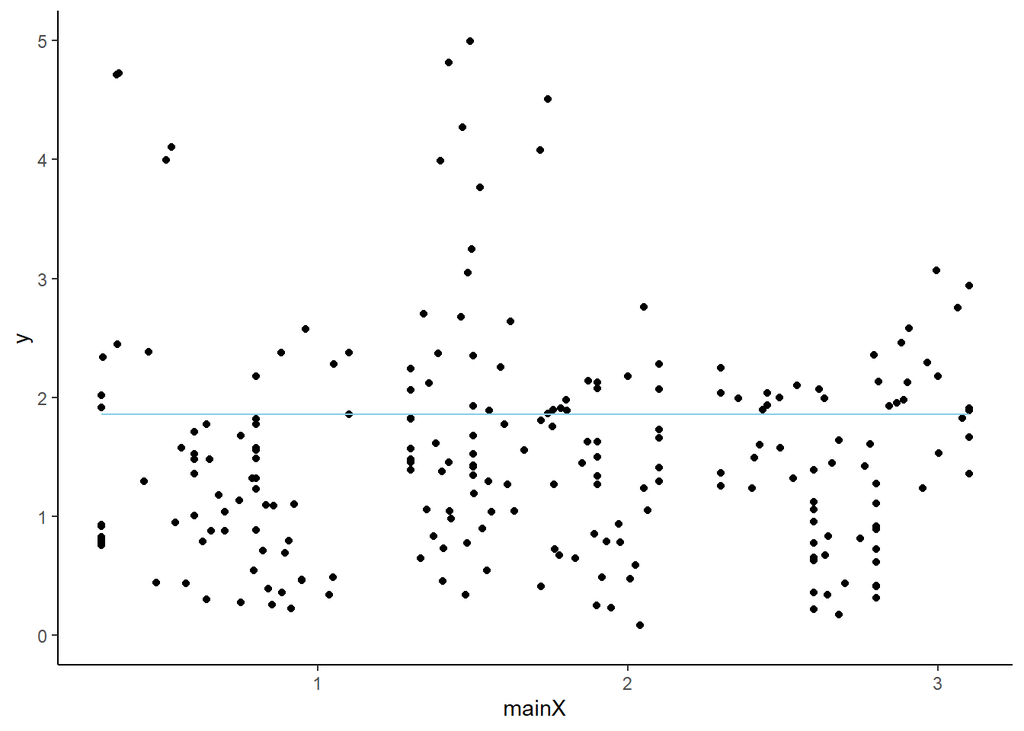

```r
ggplot(hfinal2, aes(y=y, x=mainX)) +
  geom_point() +
  stat_function(fun=function(x) coef(slm)[1], color='skyblue')+
  scale_y_continuous(limits=c(0,5)) +
  theme_classic()
```

### Final Results

The winner is…..BROTHER SAUNDERS.

This decision was very tough, as Preston had the best r-squared and adjusted r-squared for the original data, Tyler had the best r-squared for the validation, and Brother Saunders had the best adjusted r-squared for the validation. After much pondering, I decided that the most important metric was the adjusted r-squared.

```r
yh <- predict(mylm, newdata=hfinal2)
yhp <- predict(holy, newdata=pfinal2)
yht <- predict(lm23, newdata=tfinal2)
yhs <- predict(slm, newdata=final2)

ybar <- mean(final2$y)

SSTO <- sum( (final2$y - ybar)^2 )

# Compute SSE for each model using y - yhat
SSE <- sum( (final2$y - yh)^2 )
SSEt <- sum( (final2$y - yht)^2 )
SSEp <- sum( (final2$y - yhp)^2 )
SSEs <- sum( (final2$y - yhs)^2 )

# Compute R-squared for each
rs <- 1 - SSE/SSTO
rst <- 1 - SSEt/SSTO
rsp <- 1 - SSEp/SSTO
rss <- 1 - SSEs/SSTO


n <- length(final2$y) #sample siz
p <- length(coef(mylm))
pt <- length(coef(lm23)) #num. parameters in model
pp <- length(coef(holy)) #num. parameters in model
ps <- length(coef(slm)) #num. parameters in model
rsa <- 1 - (n-1)/(n-p)*SSE/SSTO
rsta <- 1 - (n-1)/(n-pt)*SSEt/SSTO
rspa <- 1 - (n-1)/(n-pp)*SSEp/SSTO
rssa <- 1 - (n-1)/(n-ps)*SSEs/SSTO

my_output_table2 <- data.frame(Model = c("True", "Tyler", "Preston", "Brother Saunders"), `Original R2` = c(summary(mylm)$r.squared, summary(lm23)$r.squared, summary(holy)$r.squared, summary(slm)$r.squared), `Orig. Adj. R-squared` = c(summary(mylm)$adj.r.squared, summary(lm23)$adj.r.squared, summary(holy)$adj.r.squared, summary(slm)$adj.r.squared), `Validation R-squared` = c(rs, rst, rsp, rss), `Validation Adj. R^2` = c(rsa, rsta, rspa, rssa))

colnames(my_output_table2) <- c("Model", "Original $R^2$", "Original Adj. $R^2$", "Validation $R^2$", "Validation Adj. $R^2$")

knitr::kable(my_output_table2, escape=TRUE, digits=4)
```

| Model | Original $R^2$ | Original Adj. $R^2$ | Validation $R^2$ | Validation Adj. $R^2$ |
| --- | --- | --- | --- | --- |
| True | 1.0000 | 1.0000 | 1.0000 | 1.00000e+00 |
| Tyler | 0.2666 | 0.2140 | 0.0046 | -6.68000e-02 |
| Preston | 1.0000 | 0.9994 | -7868992.5227 | -1.34335e+08 |
| Brother Saunders | 0.0000 | 0.0000 | 0.0000 | 0.00000e+00 |